# Data Analysis Project

STAT 420, Fall 2024, C. Easton, A. Roh, T. Toter, A. Treptow

# Introduction

In this data analysis study we applied the principles we learned during the semester to iterate on a linear regression model.

For our case study, we chose a “Wine Quality” dataset from the UC Irvine Machine Learning Repository. The data relates to red and white variants of the Portuguese vinho verde wine samples. We drew the data from the following site:

https://archive.ics.uci.edu/dataset/186/wine+quality

Each row in the dataset of wine samples contains a record of 11 numerically measured physicochemical attributes, such as acidity, residual sugar, chlorides, and pH. We combined two datasets (one for white wine and one for red wine), resulting in an additional categorical attribute for wine type.

The 12 attributes listed above served as our source predictor variables. A final attribute from the dataset measures quality, and serves as our response variable. Each quality measurement is a subjectively-assigned integer, ranging from 1 to 10. Our goal was to build a model that could use the objectively measured predictors as inputs to estimate how a human would rate each wine.

# Methods

## Setup

```r
options(repos = c(CRAN = "https://cloud.r-project.org"))
```

## Load and Examine the Data

```r
library(dplyr)
red_wine = read.csv("winequality-red.csv", sep = ";")
white_wine = read.csv("winequality-white.csv", sep = ";")
# Add categorical variables for wine type
red_wine$type = "Red"
white_wine$type = "White"
wine_data = bind_rows(red_wine, white_wine) # Combine the two datasets
wine_data$type = as.factor(wine_data$type)
str(wine_data)
```

```
## 'data.frame':    6497 obs. of  13 variables:
##  $ fixed.acidity       : num  7.4 7.8 7.8 11.2 7.4 7.4 7.9 7.3 7.8 7.5 ...
##  $ volatile.acidity    : num  0.7 0.88 0.76 0.28 0.7 0.66 0.6 0.65 0.58 0.5 ...
##  $ citric.acid         : num  0 0 0.04 0.56 0 0 0.06 0 0.02 0.36 ...
##  $ residual.sugar      : num  1.9 2.6 2.3 1.9 1.9 1.8 1.6 1.2 2 6.1 ...
##  $ chlorides           : num  0.076 0.098 0.092 0.075 0.076 0.075 0.069 0.065 0.073 0.071 ...
##  $ free.sulfur.dioxide : num  11 25 15 17 11 13 15 15 9 17 ...
##  $ total.sulfur.dioxide: num  34 67 54 60 34 40 59 21 18 102 ...
##  $ density             : num  0.998 0.997 0.997 0.998 0.998 ...
##  $ pH                  : num  3.51 3.2 3.26 3.16 3.51 3.51 3.3 3.39 3.36 3.35 ...
##  $ sulphates           : num  0.56 0.68 0.65 0.58 0.56 0.56 0.46 0.47 0.57 0.8 ...
##  $ alcohol             : num  9.4 9.8 9.8 9.8 9.4 9.4 9.4 10 9.5 10.5 ...
##  $ quality             : int  5 5 5 6 5 5 5 7 7 5 ...
##  $ type                : Factor w/ 2 levels "Red","White": 1 1 1 1 1 1 1 1 1 1 ...
```

## Remove Outliers

A few data points departed noticeably from the vast majority of the rest of the data. In the real world, we would carefully exam these points and consider why they might be abberations. However, that type of analysis is outside the scope of this modeling exercise, so we deviated from normal practices and simply removed the outliers to allow us to pursue a model that handles the remainder of the data.

We simply view the data in a table. Then, we simply view columns from biggest to smallest values, and notice that there is a wine observation with a residual sugar value of 65.80, more than double that of the next wine observation. We repeat this again for the free sulfur dioxide column, and notice that the wine observation has almost double the value as the next observation. Keeping these data will greatly hinder our ability to read and interpret the pairs plots, so we remove them.

```r
res_sugar_6580 = which(wine_data$residual.sugar == 65.80)
free_sulf_dio_289 = which(wine_data$free.sulfur.dioxide == 289.0)

remove_idx = c(res_sugar_6580, free_sulf_dio_289)
wine_data = wine_data[-remove_idx, ]
```

## Fit a Full Additive Model

We began by creating an additive model using all predictors (without transformations). This model served as a baseline to judge improvements for upcoming iterations.

```r
full_add_model = lm(quality ~ ., data = wine_data)
summary(full_add_model)
```

```
##
## Call:
## lm(formula = quality ~ ., data = wine_data)
##
## Residuals:
##     Min      1Q  Median      3Q     Max
## -3.6170 -0.4692 -0.0409  0.4573  3.0236
##
## Coefficients:
##                        Estimate Std. Error t value Pr(>|t|)
## (Intercept)           1.218e+02  1.555e+01   7.832 5.59e-15 ***
## fixed.acidity         1.004e-01  1.660e-02   6.047 1.56e-09 ***
## volatile.acidity     -1.490e+00  8.117e-02 -18.357  < 2e-16 ***
## citric.acid          -7.058e-02  7.953e-02  -0.888   0.3748
## residual.sugar        6.692e-02  6.251e-03  10.706  < 2e-16 ***
## chlorides            -7.361e-01  3.337e-01  -2.206   0.0274 *
## free.sulfur.dioxide   5.693e-03  7.783e-04   7.315 2.88e-13 ***
## total.sulfur.dioxide -1.361e-03  3.243e-04  -4.195 2.76e-05 ***
## density              -1.212e+02  1.576e+01  -7.688 1.72e-14 ***
## pH                    5.589e-01  9.287e-02   6.018 1.86e-09 ***
## sulphates             7.413e-01  7.635e-02   9.709  < 2e-16 ***
## alcohol               2.029e-01  1.967e-02  10.316  < 2e-16 ***
## typeWhite            -4.068e-01  5.887e-02  -6.910 5.33e-12 ***
## ---
## Signif. codes:  0 '***' 0.001 '**' 0.01 '*' 0.05 '.' 0.1 ' ' 1
##
## Residual standard error: 0.7312 on 6482 degrees of freedom
## Multiple R-squared:  0.2992, Adjusted R-squared:  0.2979
## F-statistic: 230.7 on 12 and 6482 DF,  p-value: < 2.2e-16
```

## Log Transformed Predictors

The predictor histograms showed that some of the predictors appear to be normally distributed, but other predictors are skewed. We experimented with a full model using log transformed variables for the ones that appeared especially skewed. We also tried a model with log transformed variables and interactive terms.

```r
model_add = lm(quality ~ ., data = wine_data)

model_log = lm(quality ~ fixed.acidity + log(volatile.acidity) + citric.acid +
                 residual.sugar + chlorides + log(free.sulfur.dioxide) +
                 total.sulfur.dioxide + density + (pH) + (sulphates) +
                 (alcohol) + type, data = wine_data)

model_log_int = lm(quality ~ (fixed.acidity + log(volatile.acidity) +
                                citric.acid + residual.sugar + chlorides +
                                log(free.sulfur.dioxide) +
                                total.sulfur.dioxide + density + (pH) +
                                (sulphates) + (alcohol) + type)^2,
                   data = wine_data)
```

## Fit a Full Interaction Model

Next, we created an interaction model using all predictors (without transformations).

```r
full_int_model = lm(quality ~ .^2, data = wine_data)
summary(full_int_model)
```

```
##
## Call:
## lm(formula = quality ~ .^2, data = wine_data)
##
## Residuals:
##     Min      1Q  Median      3Q     Max
## -3.2677 -0.4646 -0.0193  0.4387  2.9732
##
## Coefficients:
##                                            Estimate Std. Error t value Pr(>|t|)
## (Intercept)                              -5.282e+02  2.909e+02  -1.816 0.069477
## fixed.acidity                             3.301e+00  7.165e+00   0.461 0.645043
## volatile.acidity                         -4.557e+00  1.140e+02  -0.040 0.968125
## citric.acid                              -4.756e+01  1.198e+02  -0.397 0.691265
## residual.sugar                            3.043e+00  1.056e+00   2.880 0.003987
## chlorides                                -1.240e+03  5.055e+02  -2.453 0.014191
## free.sulfur.dioxide                      -3.935e+00  1.373e+00  -2.866 0.004170
## total.sulfur.dioxide                      3.609e-01  4.887e-01   0.739 0.460174
## density                                   5.423e+02  2.910e+02   1.864 0.062402
## pH                                        1.167e+02  7.408e+01   1.575 0.115332
## sulphates                                 1.014e+02  1.165e+02   0.871 0.383844
## alcohol                                   2.080e+01  6.155e+00   3.380 0.000730
## typeWhite                                 1.690e+02  6.047e+01   2.795 0.005200
## fixed.acidity:volatile.acidity           -4.018e-02  1.357e-01  -0.296 0.767202
## fixed.acidity:citric.acid                -7.160e-02  1.253e-01  -0.571 0.567803
## fixed.acidity:residual.sugar              7.843e-03  3.995e-03   1.963 0.049655
## fixed.acidity:chlorides                  -1.995e+00  5.478e-01  -3.642 0.000273
## fixed.acidity:free.sulfur.dioxide        -6.552e-04  1.422e-03  -0.461 0.644972
## fixed.acidity:total.sulfur.dioxide       -3.107e-04  5.601e-04  -0.555 0.579094
## fixed.acidity:density                    -3.943e+00  7.102e+00  -0.555 0.578742
## fixed.acidity:pH                          2.550e-01  6.641e-02   3.839 0.000125
## fixed.acidity:sulphates                   2.420e-01  1.198e-01   2.020 0.043469
## fixed.acidity:alcohol                    -1.273e-02  1.338e-02  -0.951 0.341653
## fixed.acidity:typeWhite                   9.413e-02  7.803e-02   1.206 0.227734
## volatile.acidity:citric.acid              1.057e+00  5.653e-01   1.870 0.061581
## volatile.acidity:residual.sugar          -5.721e-02  4.825e-02  -1.186 0.235807
## volatile.acidity:chlorides                2.536e+00  2.547e+00   0.995 0.319534
## volatile.acidity:free.sulfur.dioxide      1.055e-02  7.382e-03   1.429 0.153149
## volatile.acidity:total.sulfur.dioxide     5.182e-03  2.726e-03   1.901 0.057371
## volatile.acidity:density                 -3.965e+00  1.158e+02  -0.034 0.972693
```

[output cut: 120 more lines]

```
## density:sulphates
## density:alcohol                          **
## density:typeWhite                        **
## pH:sulphates                             **
## pH:alcohol
## pH:typeWhite                             ***
## sulphates:alcohol
## sulphates:typeWhite
## alcohol:typeWhite                        **
## ---
## Signif. codes:  0 '***' 0.001 '**' 0.01 '*' 0.05 '.' 0.1 ' ' 1
##
## Residual standard error: 0.6989 on 6416 degrees of freedom
## Multiple R-squared:  0.3663, Adjusted R-squared:  0.3586
## F-statistic: 47.55 on 78 and 6416 DF,  p-value: < 2.2e-16
```

## Compare the Adjusted R-Squared for Various Models

```r
summary(model_add)$adj.r.squared
```

```
## [1] 0.2979344
```

```r
summary(model_log)$adj.r.squared
```

```
## [1] 0.308821
```

```r
summary(full_int_model)$adj.r.squared
```

```
## [1] 0.3586131
```

```r
summary(model_log_int)$adj.r.squared
```

```
## [1] 0.3672656
```

## Variance Inflation Factors

We calculated the Variance Inflation Factors (VIF) to help us identify issues of multicollinearity between predictors.

```r
if (!require(car)) install.packages("car")
library(car)
vif_values = vif(full_add_model)
vif_values
```

```
##        fixed.acidity     volatile.acidity          citric.acid
##             5.628017             2.164733             1.621621
##       residual.sugar            chlorides  free.sulfur.dioxide
##            10.478670             1.660496             2.242059
## total.sulfur.dioxide              density                   pH
##             4.061444            26.218201             2.707553
##            sulphates              alcohol                 type
##             1.567837             6.685470             7.813514
```

```r
mod_log_int_cd = cooks.distance(model_log_int)

mod_log_int_fixed = lm(quality ~ (fixed.acidity + log(volatile.acidity) + citric.acid + residual.sugar + chlorides + log(free.sulfur.dioxide) + total.sulfur.dioxide + density + (pH) + (sulphates) + (alcohol) + type)^2,
                       data = wine_data,
                       subset = mod_log_int_cd < 4 / length(mod_log_int_cd))

summary(mod_log_int_fixed)$adj.r.squared
```

```
## [1] 0.4199419
```

## Akaike Information Criterion (AIC) and Bayesian Information Criteria (BIC) Modelling

```r
model_bac_aic = step(model_log_int, trace = 0)
model_bac_bic = step(model_log_int, k = log(nrow(wine_data)), trace = 0)
model_both_aic = step(model_log_int, direction = "both", trace = 0)
summary(model_bac_aic)$adj.r.squared
```

```
## [1] 0.3685138
```

```r
summary(model_bac_bic)$adj.r.squared
```

```
## [1] 0.3612216
```

```r
summary(model_both_aic)$adj.r.squared
```

```
## [1] 0.3685138
```

## Analysis of Variance (ANOVA)

```r
anova(model_bac_aic, model_log_int)
```

```
## Analysis of Variance Table
##
## Model 1: quality ~ fixed.acidity + log(volatile.acidity) + citric.acid +
##     residual.sugar + chlorides + log(free.sulfur.dioxide) + total.sulfur.dioxide +
##     density + pH + sulphates + alcohol + type + fixed.acidity:residual.sugar +
##     fixed.acidity:chlorides + fixed.acidity:density + fixed.acidity:pH +
##     fixed.acidity:sulphates + fixed.acidity:alcohol + log(volatile.acidity):citric.acid +
##     log(volatile.acidity):residual.sugar + log(volatile.acidity):log(free.sulfur.dioxide) +
##     log(volatile.acidity):pH + log(volatile.acidity):alcohol +
##     citric.acid:residual.sugar + citric.acid:alcohol + citric.acid:type +
##     residual.sugar:chlorides + residual.sugar:log(free.sulfur.dioxide) +
##     residual.sugar:total.sulfur.dioxide + residual.sugar:density +
##     chlorides:density + chlorides:pH + chlorides:sulphates +
##     log(free.sulfur.dioxide):total.sulfur.dioxide + log(free.sulfur.dioxide):density +
##     log(free.sulfur.dioxide):pH + log(free.sulfur.dioxide):sulphates +
##     log(free.sulfur.dioxide):alcohol + log(free.sulfur.dioxide):type +
##     total.sulfur.dioxide:sulphates + total.sulfur.dioxide:type +
##     density:pH + density:sulphates + density:alcohol + density:type +
##     pH:sulphates + pH:alcohol + pH:type + sulphates:alcohol +
##     alcohol:type
## Model 2: quality ~ (fixed.acidity + log(volatile.acidity) + citric.acid +
##     residual.sugar + chlorides + log(free.sulfur.dioxide) + total.sulfur.dioxide +
##     density + (pH) + (sulphates) + (alcohol) + type)^2
##   Res.Df    RSS Df Sum of Sq     F Pr(>F)
## 1   6444 3099.1
## 2   6416 3091.7 28    7.3668 0.546 0.9751
```

```r
anova(model_bac_bic, model_log_int)
```

```
## Analysis of Variance Table
##
## Model 1: quality ~ fixed.acidity + log(volatile.acidity) + residual.sugar +
##     chlorides + log(free.sulfur.dioxide) + total.sulfur.dioxide +
##     density + pH + sulphates + alcohol + type + fixed.acidity:chlorides +
##     fixed.acidity:pH + log(volatile.acidity):residual.sugar +
##     log(volatile.acidity):log(free.sulfur.dioxide) + log(volatile.acidity):alcohol +
##     residual.sugar:chlorides + residual.sugar:log(free.sulfur.dioxide) +
##     residual.sugar:total.sulfur.dioxide + chlorides:density +
##     chlorides:pH + chlorides:sulphates + log(free.sulfur.dioxide):total.sulfur.dioxide +
##     log(free.sulfur.dioxide):type + total.sulfur.dioxide:sulphates +
##     density:pH + density:type + pH:sulphates + pH:type
## Model 2: quality ~ (fixed.acidity + log(volatile.acidity) + citric.acid +
##     residual.sugar + chlorides + log(free.sulfur.dioxide) + total.sulfur.dioxide +
##     density + (pH) + (sulphates) + (alcohol) + type)^2
##   Res.Df    RSS Df Sum of Sq      F    Pr(>F)
## 1   6465 3145.1
## 2   6416 3091.7 49     53.37 2.2603 1.312e-06 ***
## ---
## Signif. codes:  0 '***' 0.001 '**' 0.01 '*' 0.05 '.' 0.1 ' ' 1
```

```r
anova(model_both_aic, model_log_int)
```

```
## Analysis of Variance Table
##
## Model 1: quality ~ fixed.acidity + log(volatile.acidity) + citric.acid +
##     residual.sugar + chlorides + log(free.sulfur.dioxide) + total.sulfur.dioxide +
##     density + pH + sulphates + alcohol + type + fixed.acidity:residual.sugar +
##     fixed.acidity:chlorides + fixed.acidity:density + fixed.acidity:pH +
##     fixed.acidity:sulphates + fixed.acidity:alcohol + log(volatile.acidity):citric.acid +
##     log(volatile.acidity):residual.sugar + log(volatile.acidity):log(free.sulfur.dioxide) +
##     log(volatile.acidity):pH + log(volatile.acidity):alcohol +
##     citric.acid:residual.sugar + citric.acid:alcohol + citric.acid:type +
##     residual.sugar:chlorides + residual.sugar:log(free.sulfur.dioxide) +
##     residual.sugar:total.sulfur.dioxide + residual.sugar:density +
##     chlorides:density + chlorides:pH + chlorides:sulphates +
##     log(free.sulfur.dioxide):total.sulfur.dioxide + log(free.sulfur.dioxide):density +
##     log(free.sulfur.dioxide):pH + log(free.sulfur.dioxide):sulphates +
##     log(free.sulfur.dioxide):alcohol + log(free.sulfur.dioxide):type +
##     total.sulfur.dioxide:sulphates + total.sulfur.dioxide:type +
##     density:pH + density:sulphates + density:alcohol + density:type +
##     pH:sulphates + pH:alcohol + pH:type + sulphates:alcohol +
##     alcohol:type
## Model 2: quality ~ (fixed.acidity + log(volatile.acidity) + citric.acid +
##     residual.sugar + chlorides + log(free.sulfur.dioxide) + total.sulfur.dioxide +
##     density + (pH) + (sulphates) + (alcohol) + type)^2
##   Res.Df    RSS Df Sum of Sq     F Pr(>F)
## 1   6444 3099.1
## 2   6416 3091.7 28    7.3668 0.546 0.9751
```

# Results

## Predictor Scatterplots

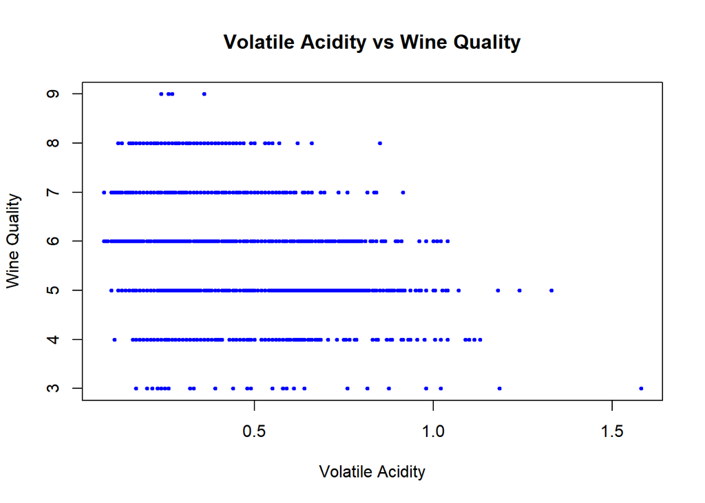

```r
plot(wine_data$volatile.acidity, wine_data$quality,
     main = "Volatile Acidity vs Wine Quality",
     xlab = "Volatile Acidity",
     ylab = "Wine Quality",
     col = "blue", pch = 19, cex = 0.5)
```

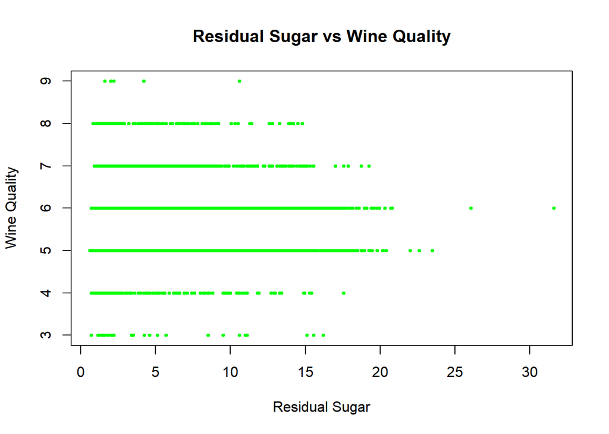

```r
plot(wine_data$residual.sugar, wine_data$quality,
     main = "Residual Sugar vs Wine Quality",
     xlab = "Residual Sugar",
     ylab = "Wine Quality",
     col = "green", pch = 19, cex = 0.5)
```

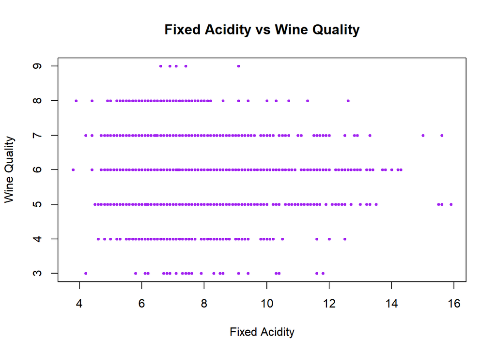

```r
plot(wine_data$fixed.acidity, wine_data$quality,
     main = "Fixed Acidity vs Wine Quality",
     xlab = "Fixed Acidity",
     ylab = "Wine Quality",
     col = "purple", pch = 19, cex = 0.5)
```

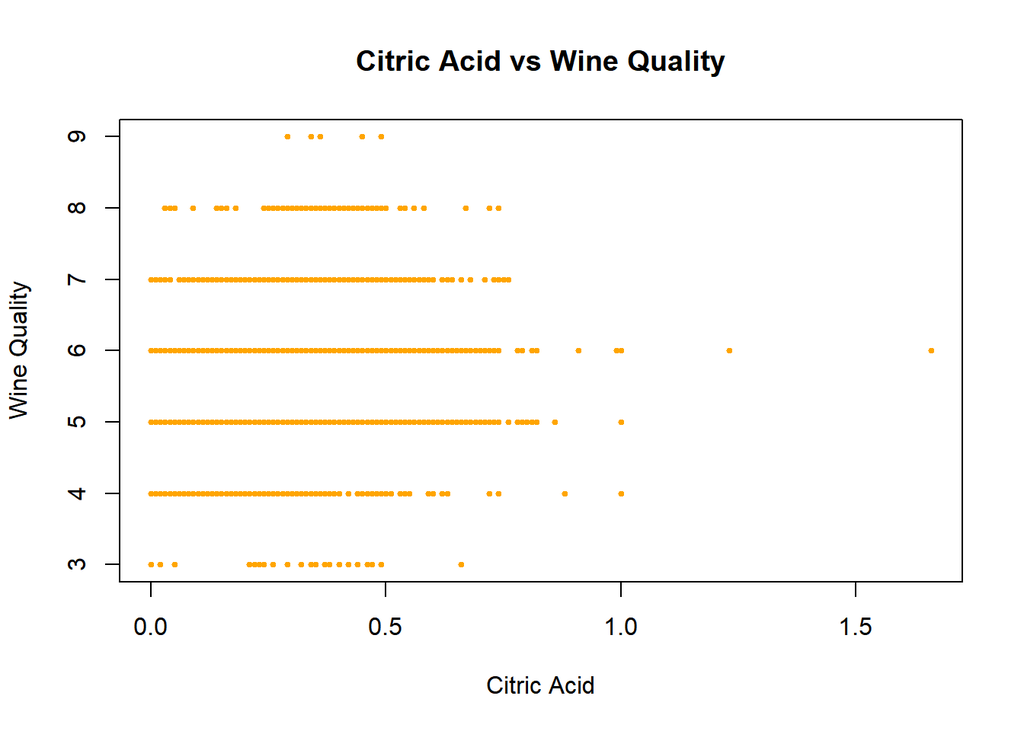

```r
plot(wine_data$citric.acid, wine_data$quality,
     main = "Citric Acid vs Wine Quality",
     xlab = "Citric Acid",
     ylab = "Wine Quality",
     col = "orange", pch = 19, cex = 0.5)
```

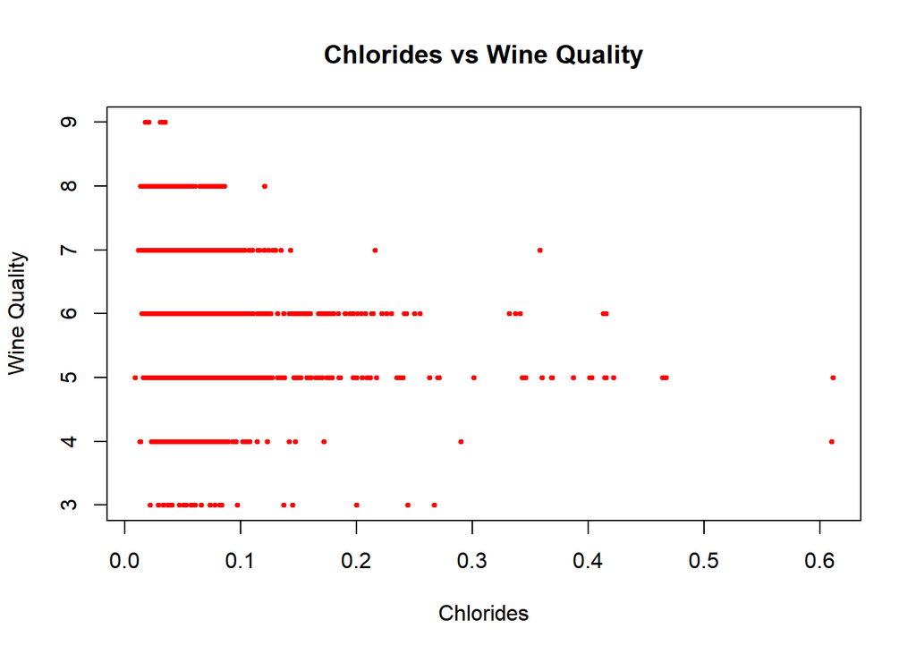

```r
plot(wine_data$chlorides, wine_data$quality,
     main = "Chlorides vs Wine Quality",
     xlab = "Chlorides",
     ylab = "Wine Quality",
     col = "red", pch = 19, cex = 0.5)
```

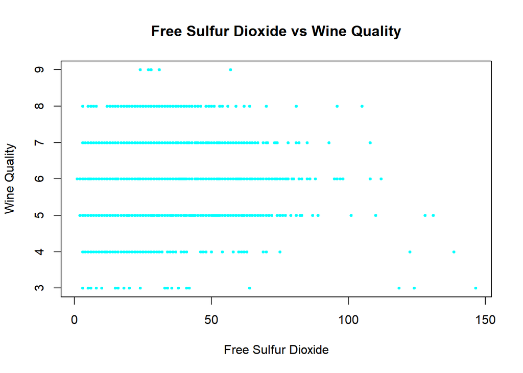

```r
plot(wine_data$free.sulfur.dioxide, wine_data$quality,
     main = "Free Sulfur Dioxide vs Wine Quality",
     xlab = "Free Sulfur Dioxide",
     ylab = "Wine Quality",
     col = "cyan", pch = 19, cex = 0.5)
```

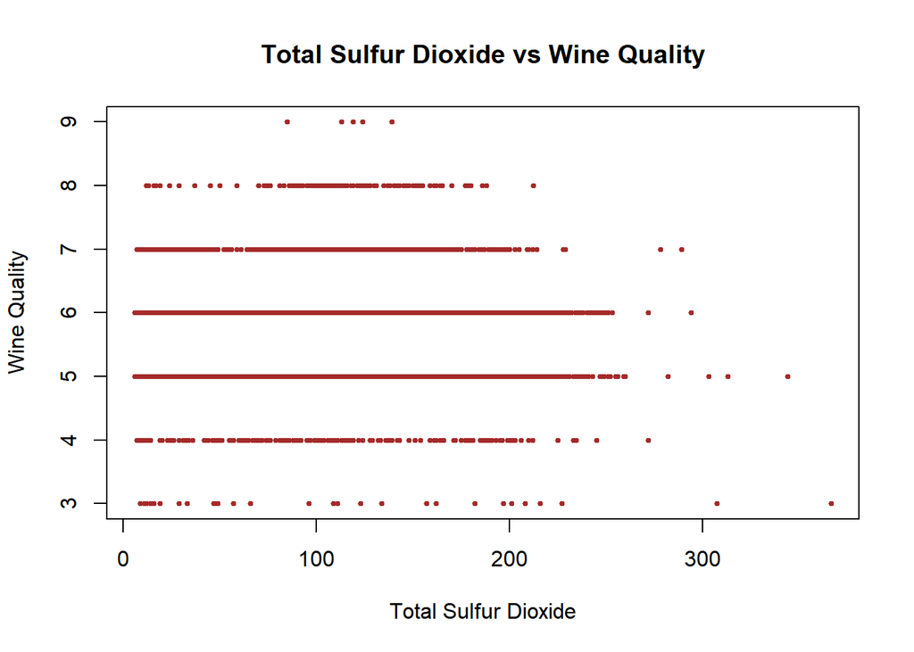

```r
plot(wine_data$total.sulfur.dioxide, wine_data$quality,
     main = "Total Sulfur Dioxide vs Wine Quality",
     xlab = "Total Sulfur Dioxide",
     ylab = "Wine Quality",
     col = "brown", pch = 19, cex = 0.5)
```

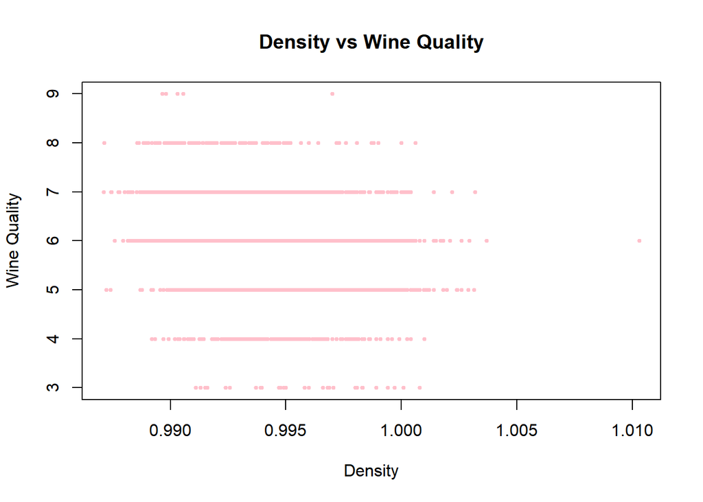

```r
plot(wine_data$density, wine_data$quality,
     main = "Density vs Wine Quality",
     xlab = "Density",
     ylab = "Wine Quality",
     col = "pink", pch = 19, cex = 0.5)
```

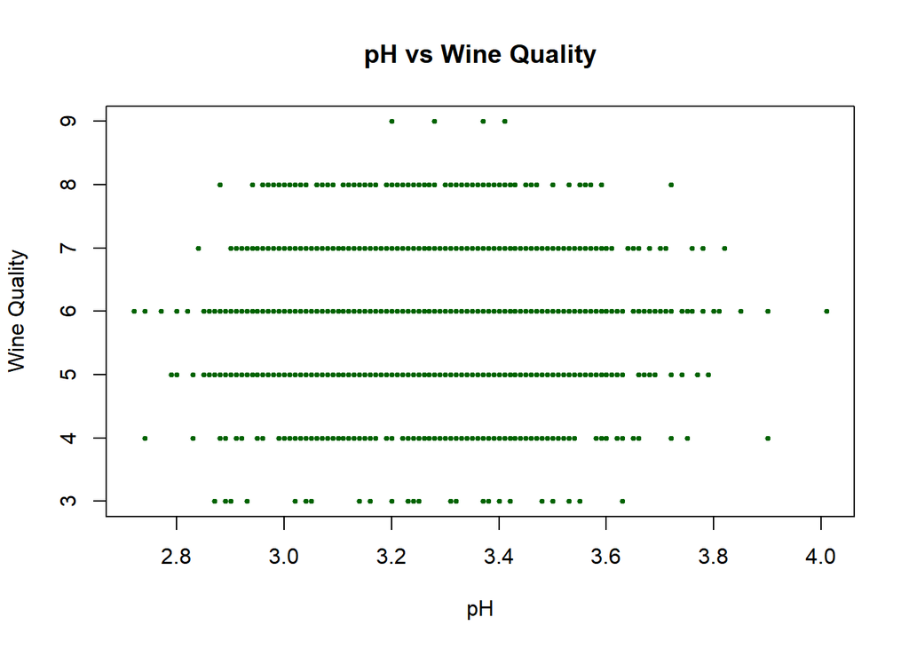

```r
plot(wine_data$pH, wine_data$quality,
     main = "pH vs Wine Quality",
     xlab = "pH",
     ylab = "Wine Quality",
     col = "darkgreen", pch = 19, cex = 0.5)
```

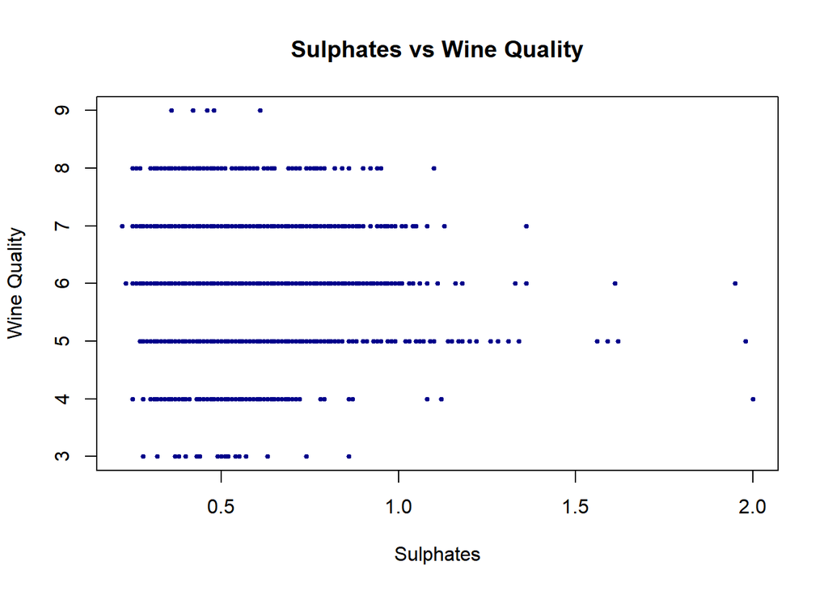

```r
plot(wine_data$sulphates, wine_data$quality,
     main = "Sulphates vs Wine Quality",
     xlab = "Sulphates",
     ylab = "Wine Quality",
     col = "darkblue", pch = 19, cex = 0.5)
```

## Predictor Histograms

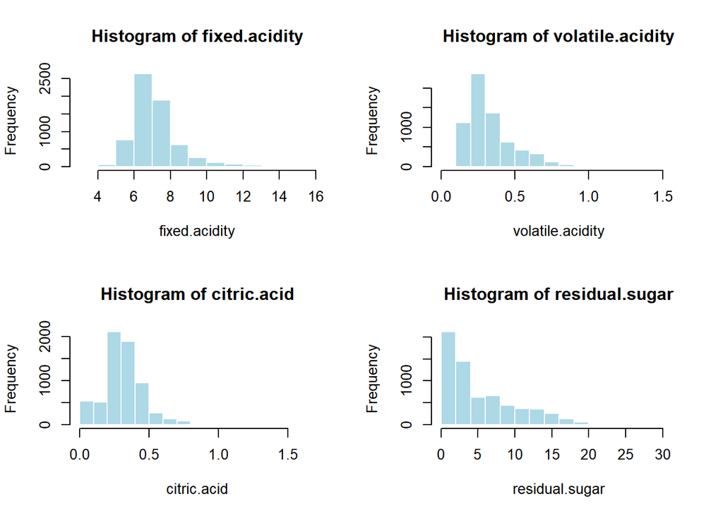

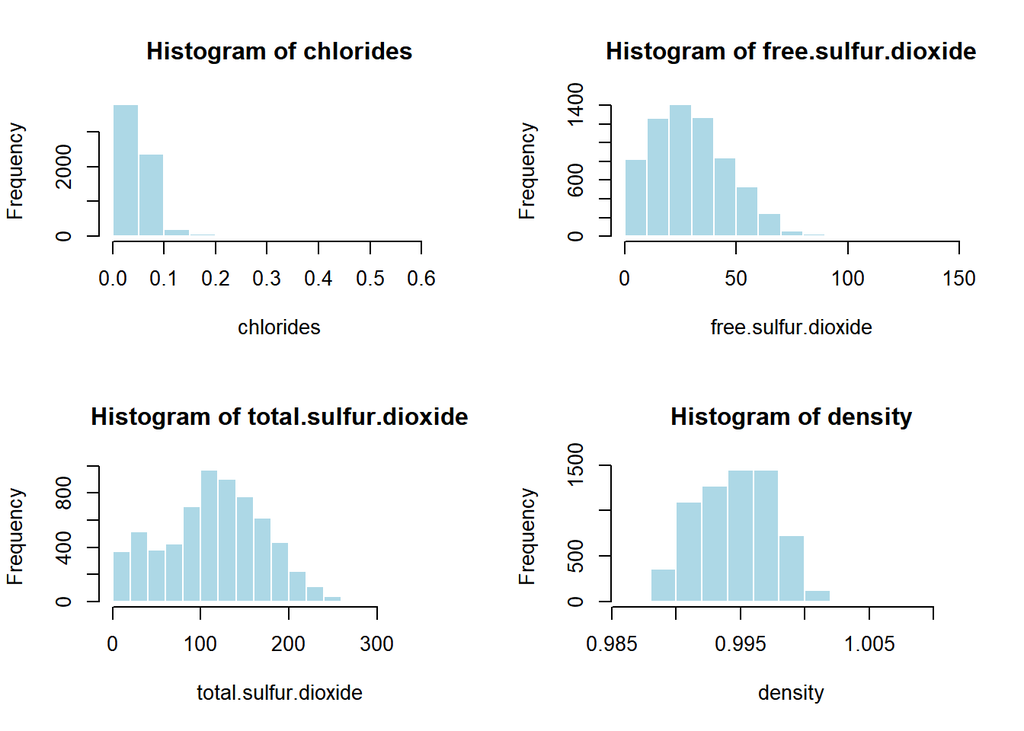

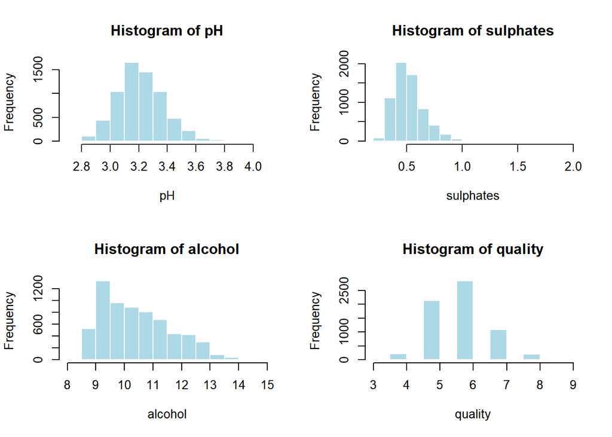

[output not shown]

```r
numeric_columns = wine_data[sapply(wine_data, is.numeric)]
par(mfrow = c(2, 2))
sapply(names(numeric_columns), function(column) {
  hist(numeric_columns[[column]], main = paste("Histogram of", column),
       xlab = column, col = "lightblue", border = "white")
})
```

## Predictor Correlation Heatmap

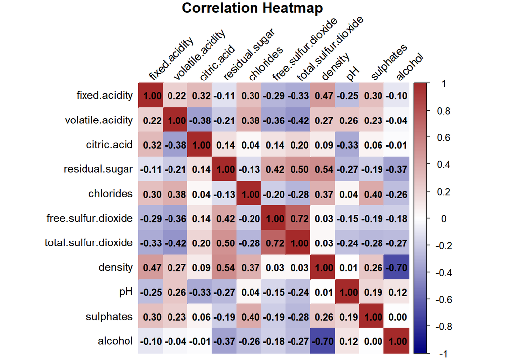

```r
if (!require(corrplot)) install.packages("corrplot")
library(corrplot)

numeric_data = wine_data %>%
  select(-type, -quality) # Considers numeric predictors only
cor_matrix = cor(numeric_data, use = "complete.obs")
par(mar = c(0, 0, 5, 0))
corrplot(cor_matrix,
         method = "color",
         addCoef.col = "black",
         tl.cex = 0.9,
         tl.col = "black",
         tl.srt = 45,
         number.cex = 0.8,
         main = "Correlation Heatmap",
         cl.cex = 0.8,
         cl.ratio = 0.2,
         mar = c(0, 0, 1, 0),
         col = colorRampPalette(c("navy", "white", "brown"))(200)
)
```

## Linear Model Assumption Diagnostic Plots

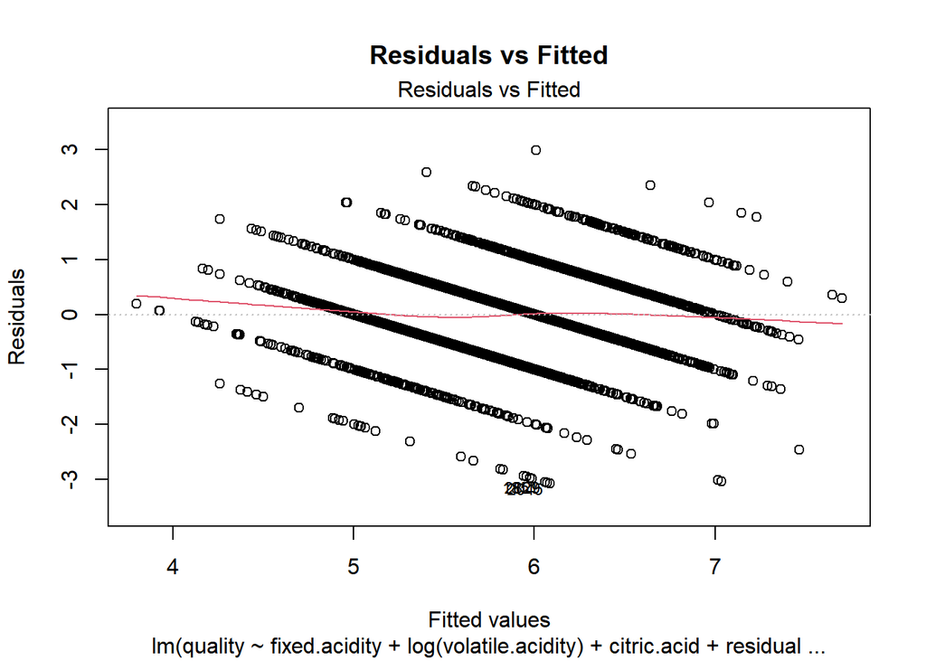

```r
plot(model_both_aic, which = 1, main = "Residuals vs Fitted")
```

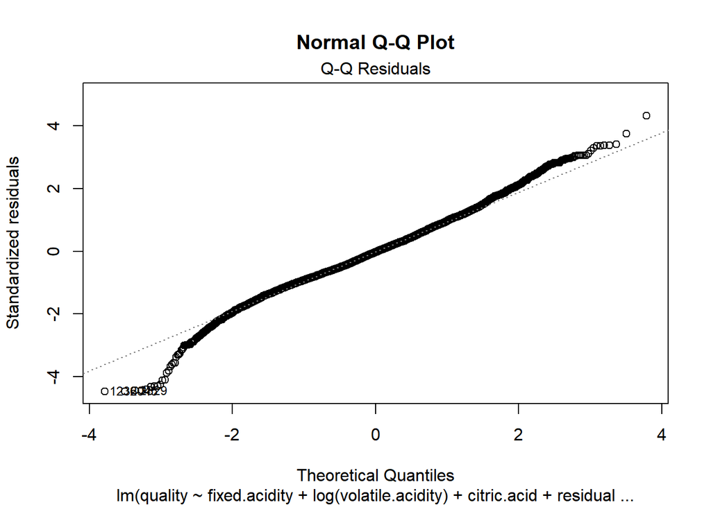

```r
plot(model_both_aic, which = 2, main = "Normal Q-Q Plot")
```

# Discussion

Importantly, we did a final check on our final model to ensure that it obeyed the linear model assumptions.